# Bitcoin Factor Analysis

## R Packages

- The [devtools package](https://cran.r-project.org/package=devtools) contains the `install_github()` function, which allows us to install packages directly from GitHub. This will let us install the geckor package, which is no longer published to CRAN.
- The [geckor package](https://github.com/next-game-solutions/geckor) is a wrapper for the [CoinGecko API](https://www.coingecko.com/en/api) and allows for easy import of bitcoin price data.
- The [dplyr package](https://cran.r-project.org/package=dplyr) contains tools for data transformations.
- The [xts package](https://cran.r-project.org/package=xts) is short for ‘eXtensible Time Series’, which contains tools for working with time series data.
- The [lubridate package](https://cran.r-project.org/package=tseries) contains tools for working with date-math.
- The [readr package](https://cran.r-project.org/package=readr) is a common package for reading in factor data files. After installing, the RStudio Environment tab will have a new option to import data sets that uses this package. It will even generate the R code for you to copy and paste into your script.
- The [jsonlite package](https://cran.r-project.org/package=jsonlite) lets us more easily import JSON data.
- The [ggplot2 package](https://cran.r-project.org/package=ggplot2) for graphics and visuals.
- The [tseries package](https://cran.r-project.org/package=tseries) contains additional time series analysis functions that we will explore.
- The [rmarkdown package](https://cran.r-project.org/package=rmarkdown) is used to generate this R Notebook.

```r
# Create list of packages needed for this exercise, omit geckor since its not on CRAN
list.of.packages = c("devtools","dplyr","xts","readr","jsonlite","ggplot2","tseries","rmarkdown")
# Check if any have not yet been installed
new.packages = list.of.packages[!(list.of.packages %in% installed.packages()[,"Package"])]
# If any need to be installed, install them
if(length(new.packages)) install.packages(new.packages)
# Since geckor is no longer published to CRAN, install via GitHub
library(devtools)
devtools::install_github("next-game-solutions/geckor")
```

```r
# Load in the remaining packages
library(geckor)
library(dplyr)
library(xts)
library(lubridate)
library(readr)
library(jsonlite)
library(ggplot2)
library(tseries)
```

## Data Imports

This section will build out a cleaned dataset for use in the subsequent analysis. To start, we’ll import crypto price data from CoinGecko. Then we’ll import factor data from Kenneth French’s website to see if known equity factors explain bitcoin returns. Next, we’ll import some more bitcoin-specific data to make a more tailored asset pricing model.

### Crypto Price Data

To start, we’ll import bitcoin price data using the geckor R package, which imports data via the [CoinGecko API](https://www.coingecko.com/en/api). Then for some additional points of comparison, we’ll also import the price data for ether (ETH; ethereum) and wrapped bitcoin (WBTC).

```r
startdate = "2013-04-27"
coinids = c("bitcoin","ethereum","wrapped-bitcoin")
prices = coin_history_range(coin_id=coinids,
                            vs_currency = "usd",
                            from = as.POSIXct(startdate),
                            to = as.POSIXct(Sys.Date()))
```

```
Warning: Missing values found in column(s)
• market_capWarning: Missing values found in column(s)
• market_cap
```

Interestingly, as of January 2024, the above import code produces a warning of some missing values in the market_cap column. If we more closely examine (use `which()` and `is.na()` to identify the row numbers of the missing values), these missing values appear to be for April 2, 2017. Not sure why exactly this is, but since we have price data on each of those days, we can impute these values without too much difficulty.

```r
# Identify indices of missing values
missinginds = which(is.na(prices$market_cap))
prices[missinginds,]
```

| timestamp | coin_id | vs_currency | price | total_volume | market_cap |
| --- | --- | --- | --- | --- | --- |
| 2017-04-02 | bitcoin | usd | 1098.06800 | 80231506 | NA |
| 2017-04-02 | ethereum | usd | 48.37847 | 86493796 | NA |

```r
for (i in missinginds){
  # Subset data to 3-day period from [-1,1]
  subprice = prices[(i-1):(i+1),]
  # Create ncoins variable by dividing market cap by price
  subprice$ncoins = subprice$market_cap/subprice$price
  # Impute missing value with average of day before and day after
  subprice$ncoins[2] = (subprice$ncoins[1]+subprice$ncoins[3])/2
  # Compute missing market cap as price*ncoins
  subprice$market_cap[2] = subprice$ncoins[2]*subprice$price[2]
  # Move imputed value back to main data frame
  prices$market_cap[i] = subprice$market_cap[2]
}
sum(is.na(prices)) # Verify no more missing values
```

```
[1] 0
```

#### Crypto Data Cleaning

Since the data format for each coin is similar, we can loop the data cleaning process to simplify the scalability of the code. So if we add more cryptos to analyze, we shouldn’t need to change any of this cleaning code below. The comments in the code chunk should help clarify the individual steps, but generally, it isolates the observations for each coin, and then transforms the OHLCV data into an xts object. Since some of the daily factors that we plan to explore only are observed at a business-day frequency (and to focus on longer-term trends), we’ll expand out to the monthly frequency with the price data. Then we transform the monthly prices to annualized returns to resolve the autocorrelation of the price series.

As an alternative measure, we’ll measure the annualized growth rate of the market capitalization. With the gradual mining of new BTC into existence, these growth rates will slightly outperform the price appreciation (returns). However, as the halving cycles continue and the upper-bound of 21 million BTC is approached, this gap between these measurements will get smaller. When measuring financial returns, the former (price-driven) return will be more appropriate, and for a more general measurement of the growth in the economic magnitude of Bitcoin, the latter (market-cap-driven) return will be more appropriate.

Lastly, since the OHLCV data includes daily trading volumes (which converted to monthly totals), we’ll consider this a potential factor in our analysis. In regard to interpretability, an elasticity interpretation (percent change in volume leads to a beta percent change in price) seems most appropriate here, so we’ll transform the monthly trading volume into an annualized growth rate to explore as a factor.

```r
dfs_month = list()

#coin = coinids[1] # This line is used for troubleshooting the code inside the for loop below
### To troubleshoot, uncomment the line above, and then comment out the for and } lines.
for (coin in coinids) {
  # Extract price data for each coin
  subdf = filter(prices, coin_id==coin)
  # Create xts object for each frequency
  dailyxts = xts(subdf[,4:6], order.by=as.Date(subdf$timestamp))
  monthxts = to.monthly(dailyxts)
  # Calculate annualized return of the coin's price movements
  monthxts$logprice = log(monthxts$dailyxts.Close)
  monthxts$annret = (monthxts$logprice - lag(monthxts$logprice))*12*100
  #monthxts$annret = (log(as.numeric(monthxts$dailyxts.Close)) - log(as.numeric(lag(monthxts$dailyxts.Close))))*12*100
  # Calculate alternative annualized return measurement from the market cap of the coin
  # Since to.monthly only converts OHLCV data by default, we must run again for market caps.
  monthxts2 = to.monthly(dailyxts$market_cap)
  monthxts$annret2 = (log(as.numeric(monthxts2$`dailyxts$market_cap.Close`)) - log(as.numeric(lag(monthxts2$`dailyxts$market_cap.Close`))))*12*100
  # Calculate volume growth rates
  monthxts$logvolume = log(monthxts$dailyxts.Volume)
  monthxts$volgrowth = (monthxts$logvolume - lag(monthxts$logvolume))*12*100
  # Calculate within-month volatility of annualized daily returns
  dailyxts$logprice = log(dailyxts$price)
  dailyxts$annret = (dailyxts$logprice - lag(dailyxts$logprice))*365*100
  monthxts3 = apply.monthly(dailyxts$annret, FUN=sd)
    # Fix dates from end of month to beginning of month like rest of data
    index(monthxts3) = ceiling_date(index(monthxts3), unit="month") - months(1)
  monthxts$dailyannretsd = monthxts3
  # Calculate within-month volatility in annualized volume growth rates
  dailyxts$logvolume = log(dailyxts$total_volume)
  dailyxts$volgrowth = (dailyxts$logvolume - lag(dailyxts$logvolume))*365*100
  monthxts4 = apply.monthly(dailyxts$volgrowth, FUN=sd)
    # Fix dates from end of month to beginning of month like rest of data
    index(monthxts4) = ceiling_date(index(monthxts4), unit="month") - months(1)
  monthxts$dailyannvolsd = monthxts4
  # Save data frames to output object
  dfs_month[[coin]] = monthxts
}
```

### Fama/French Factors

Another set of factors to consider are the Fama/French Factors. The earlier Fama and French (1993) paper introduced a three-factor model that includes SMB (Small Minus Big) as a ‘size’ factor and HML (High Minus Low) as a ‘value’/‘growth’ factor. See [the 3-Factors webpage](https://mba.tuck.dartmouth.edu/pages/faculty/ken.french/Data_Library/f-f_factors.html) for more detail. The data is also available there at the url in the data chunk below. Since these are available as compressed folders, we must first download the file (we’ll put it in a sub-folder, Factor Data) and then decompress (unzip) the file before reading in the data. Then the last few steps clean up the data, format to xts, and delete the pre-Bitcoin data.

```r
ff3url = "https://mba.tuck.dartmouth.edu/pages/faculty/ken.french/ftp/F-F_Research_Data_Factors_CSV.zip"
# Create subdirectory for file downloads
subdirectory = "Factor Data"
dir.create(subdirectory, showWarnings=FALSE)
# Define the file paths
zip_filepath = file.path(subdirectory, "FF3-factors.zip")
csv_filepath = file.path(subdirectory, "FF3-factors.csv")
# Download the zip file
download.file(ff3url, destfile=zip_filepath)
# Extract the CSV file from the zip file
unzip(zip_filepath, exdir=subdirectory)
# The file name in the line below comes from the name of the file within the zipped file
file.rename("Factor Data/F-F_Research_Data_Factors.CSV", csv_filepath)
```

```
[1] TRUE
```

```r
FF3 = read_csv(csv_filepath,
               col_types = cols(...1 = col_date(format = "%Y%m")),
               skip = 2)
```

```
  dat <- vroom(...)
  problems(dat)
```

The code chunk above reports a warning about some parsing errors. So let’s investigate with `problems()`.

```r
problems(FF3)
```

| row | col | expected | actual | file |
| --- | --- | --- | --- | --- |
| 1171 | 1 | 5 columns | 1 columns | C:/Users/Work/Projects/GitHub/bitcoin-projects/Factor Analysis R Notebook/Factor Data/FF3-factors.csv |
| 1171 | 1 | date like %Y%m | Annual Factors: January-December | C:/Users/Work/Projects/GitHub/bitcoin-projects/Factor Analysis R Notebook/Factor Data/FF3-factors.csv |
| 1172 | 2 | a double | Mkt-RF | C:/Users/Work/Projects/GitHub/bitcoin-projects/Factor Analysis R Notebook/Factor Data/FF3-factors.csv |
| 1172 | 3 | a double | SMB | C:/Users/Work/Projects/GitHub/bitcoin-projects/Factor Analysis R Notebook/Factor Data/FF3-factors.csv |
| 1172 | 4 | a double | HML | C:/Users/Work/Projects/GitHub/bitcoin-projects/Factor Analysis R Notebook/Factor Data/FF3-factors.csv |
| 1172 | 5 | a double | RF | C:/Users/Work/Projects/GitHub/bitcoin-projects/Factor Analysis R Notebook/Factor Data/FF3-factors.csv |
| 1173 | 1 | date like %Y%m | 1927 | C:/Users/Work/Projects/GitHub/bitcoin-projects/Factor Analysis R Notebook/Factor Data/FF3-factors.csv |
| 1174 | 1 | date like %Y%m | 1928 | C:/Users/Work/Projects/GitHub/bitcoin-projects/Factor Analysis R Notebook/Factor Data/FF3-factors.csv |
| 1175 | 1 | date like %Y%m | 1929 | C:/Users/Work/Projects/GitHub/bitcoin-projects/Factor Analysis R Notebook/Factor Data/FF3-factors.csv |
| 1176 | 1 | date like %Y%m | 1930 | C:/Users/Work/Projects/GitHub/bitcoin-projects/Factor Analysis R Notebook/Factor Data/FF3-factors.csv |

[output cut: 94 more lines]

Note how it refers us to the bottom of the data frame. These are the annual observations that are included below the monthly data. Since those annual dates do not import and are missing, we can use `complete.cases()` to easily identify the appropriate columns to retain. Then the date variable imports with an unusual name of `...1`, so we’ll fix that, and then reformat to an xts object. Lastly, we use the `paste()` function to generate a string of `"2013-04-27/"`. This type of indexing is part of the xts package, and the `/` separates a start date from an end date.

```r
# Trim annual observations from bottom of date frame (dates import as missing)
FF3 = FF3[complete.cases(FF3),]
# Fix date variable name
FF3 = FF3 |> rename(Date=...1)
# Reformat to xts object
FF3xts = xts(FF3[,-1], order.by=FF3$Date)
# Remove data prior to first BTC observation
FF3xts = FF3xts[paste(startdate,"/",sep="")]
# Annualize factor data to match annualized return scaling
FF3xts = FF3xts*12
```

More recently, [Fama and French (2015)](https://doi.org/10.1016/j.jfineco.2014.10.010) includes two additional factors: RMW (Robust Minus Weak) as a ‘profitability’ factor and CMA (Conservative Minus Aggressive) factor. The [5-Factors webpage](https://mba.tuck.dartmouth.edu/pages/faculty/ken.french/Data_Library/f-f_5_factors_2x3.html) has more detail.

```r
ff5url = "https://mba.tuck.dartmouth.edu/pages/faculty/ken.french/ftp/F-F_Research_Data_5_Factors_2x3_CSV.zip"
# Define the file paths
zip_filepath = file.path(subdirectory, "FF5-factors.zip")
csv_filepath = file.path(subdirectory, "FF5-factors.csv")
# Download the zip file
download.file(ff5url, destfile=zip_filepath)
# Extract the CSV file from the zip file
unzip(zip_filepath, exdir=subdirectory)
file.rename("Factor Data/F-F_Research_Data_5_Factors_2x3.CSV", csv_filepath)
```

```
[1] TRUE
```

```r
FF5 = read_csv(csv_filepath,
               col_types = cols(...1 = col_date(format = "%Y%m")),
               skip = 2)
```

```
  dat <- vroom(...)
  problems(dat)
```

```r
# Trim annual observations from bottom of date frame (dates import as missing)
FF5 = FF5[complete.cases(FF5),]
# Fix date variable name
FF5 = FF5 |> rename(Date=...1)
# Reformat numbers to numeric type and annualize
FF5$`Mkt-RF` = as.numeric(FF5$`Mkt-RF`)*12
FF5$SMB = as.numeric(FF5$SMB)*12
FF5$HML = as.numeric(FF5$HML)*12
FF5$RMW = as.numeric(FF5$RMW)*12
FF5$CMA = as.numeric(FF5$CMA)*12
FF5$RF = as.numeric(FF5$RF)*12
# Reformat to xts object
FF5xts = xts(FF5[,-1], order.by=FF5$Date)
# Remove data prior to first BTC observation
FF5xts = FF5xts[paste(startdate,"/",sep="")]
```

## Factor Model Regressions

### Trading Volume Growth as a Factor

Let’s start with just the crypto data and explore the idea of using growth in trading volume as a factor to explain crypto returns. This will also provide some structure to the following sets of regressions in regard to aggregating data across the various xts objects and running the regressions.

```r
# Select relevant variables and merge into a single xts object
assets_volregs = merge(dfs_month$bitcoin$annret,
                       dfs_month$bitcoin$annret2,
                       dfs_month$bitcoin$volgrowth,
                       dfs_month$ethereum$annret,
                       dfs_month$ethereum$annret2,
                       dfs_month$ethereum$volgrowth,
                       dfs_month$`wrapped-bitcoin`$annret,
                       dfs_month$`wrapped-bitcoin`$annret2,
                       dfs_month$`wrapped-bitcoin`$volgrowth)
# Give unique variable names
colnames(assets_volregs) = c("BTC_PriceRet", "BTC_MktCapRet", "BTC_VolGrowth",
                         "ETH_PriceRet", "ETH_MktCapRet", "ETH_VolGrowth",
                         "WBTC_PriceRet", "WBTC_MktCapRet", "WBTC_VolGrowth")
# Bitcoin Regressions
volregBTC1 = lm(BTC_PriceRet~BTC_VolGrowth, data=assets_volregs[is.finite(assets_volregs$BTC_VolGrowth)])
summary(volregBTC1)
```

```
Call:
lm(formula = BTC_PriceRet ~ BTC_VolGrowth, data = assets_volregs[is.finite(assets_volregs$BTC_VolGrowth)])

Residuals:
    Min      1Q  Median      3Q     Max
-567.83 -171.36    3.88  180.39  505.09

Coefficients:
              Estimate Std. Error t value Pr(>|t|)
(Intercept)   34.47835   23.24691   1.483   0.1407
BTC_VolGrowth  0.07115    0.03363   2.115   0.0365 *
---
Signif. codes:  0 ‘***’ 0.001 ‘**’ 0.01 ‘*’ 0.05 ‘.’ 0.1 ‘ ’ 1

Residual standard error: 254.1 on 119 degrees of freedom
Multiple R-squared:  0.03624,   Adjusted R-squared:  0.02814
F-statistic: 4.475 on 1 and 119 DF,  p-value: 0.03648
```

```r
volregBTC2 = lm(BTC_MktCapRet~BTC_VolGrowth, data=assets_volregs[is.finite(assets_volregs$BTC_VolGrowth)])
summary(volregBTC2)
```

```
Call:
lm(formula = BTC_MktCapRet ~ BTC_VolGrowth, data = assets_volregs[is.finite(assets_volregs$BTC_VolGrowth)])

Residuals:
   Min     1Q Median     3Q    Max
-569.7 -172.9    0.9  182.7  504.1

Coefficients:
              Estimate Std. Error t value Pr(>|t|)
(Intercept)   39.12643   23.20308   1.686   0.0944 .
BTC_VolGrowth  0.07184    0.03357   2.140   0.0344 *
---
Signif. codes:  0 ‘***’ 0.001 ‘**’ 0.01 ‘*’ 0.05 ‘.’ 0.1 ‘ ’ 1

Residual standard error: 253.6 on 119 degrees of freedom
Multiple R-squared:  0.03706,   Adjusted R-squared:  0.02897
F-statistic:  4.58 on 1 and 119 DF,  p-value: 0.03438
```

```r
# Ethereum Regressions
volregETH1 = lm(ETH_PriceRet~ETH_VolGrowth, data=assets_volregs[is.finite(assets_volregs$ETH_VolGrowth)])
summary(volregETH1)
```

```
Call:
lm(formula = ETH_PriceRet ~ ETH_VolGrowth, data = assets_volregs[is.finite(assets_volregs$ETH_VolGrowth)])

Residuals:
    Min      1Q  Median      3Q     Max
-807.65 -242.14   29.92  240.62  648.42

Coefficients:
              Estimate Std. Error t value Pr(>|t|)
(Intercept)   45.40229   33.38416   1.360    0.177
ETH_VolGrowth  0.41176    0.05272   7.811  6.1e-12 ***
---
Signif. codes:  0 ‘***’ 0.001 ‘**’ 0.01 ‘*’ 0.05 ‘.’ 0.1 ‘ ’ 1

Residual standard error: 330.6 on 99 degrees of freedom
Multiple R-squared:  0.3813,    Adjusted R-squared:  0.375
F-statistic: 61.01 on 1 and 99 DF,  p-value: 6.095e-12
```

```r
volregETH2 = lm(ETH_MktCapRet~ETH_VolGrowth, data=assets_volregs[is.finite(assets_volregs$ETH_VolGrowth)])
summary(volregETH2)
```

```
Call:
lm(formula = ETH_MktCapRet ~ ETH_VolGrowth, data = assets_volregs[is.finite(assets_volregs$ETH_VolGrowth)])

Residuals:
    Min      1Q  Median      3Q     Max
-804.81 -250.16   29.15  242.74  655.32

Coefficients:
              Estimate Std. Error t value Pr(>|t|)
(Intercept)   51.14039   33.39011   1.532    0.129
ETH_VolGrowth  0.41365    0.05273   7.845 5.15e-12 ***
---
Signif. codes:  0 ‘***’ 0.001 ‘**’ 0.01 ‘*’ 0.05 ‘.’ 0.1 ‘ ’ 1

Residual standard error: 330.7 on 99 degrees of freedom
Multiple R-squared:  0.3833,    Adjusted R-squared:  0.3771
F-statistic: 61.54 on 1 and 99 DF,  p-value: 5.147e-12
```

```r
# Wrapped Bitcoin Regressions
volregWBTC1 = lm(WBTC_PriceRet~WBTC_VolGrowth, data=assets_volregs[is.finite(assets_volregs$WBTC_VolGrowth)])
summary(volregWBTC1)
```

```
Call:
lm(formula = WBTC_PriceRet ~ WBTC_VolGrowth, data = assets_volregs[is.finite(assets_volregs$WBTC_VolGrowth)])

Residuals:
    Min      1Q  Median      3Q     Max
-585.14 -192.97   -0.18  175.94  476.02

Coefficients:
               Estimate Std. Error t value Pr(>|t|)
(Intercept)    40.80397   33.56231   1.216    0.229
WBTC_VolGrowth  0.03843    0.04234   0.908    0.368

Residual standard error: 248 on 57 degrees of freedom
Multiple R-squared:  0.01425,   Adjusted R-squared:  -0.003045
F-statistic: 0.8239 on 1 and 57 DF,  p-value: 0.3679
```

```r
volregWBTC2 = lm(WBTC_MktCapRet~WBTC_VolGrowth, data=assets_volregs[is.finite(assets_volregs$WBTC_MktCapRet)])
summary(volregWBTC2)
```

```
Call:
lm(formula = WBTC_MktCapRet ~ WBTC_VolGrowth, data = assets_volregs[is.finite(assets_volregs$WBTC_MktCapRet)])

Residuals:
    Min      1Q  Median      3Q     Max
-637.23 -118.15    0.98  134.00  518.97

Coefficients:
               Estimate Std. Error t value Pr(>|t|)
(Intercept)    54.48300   41.56864   1.311    0.198
WBTC_VolGrowth  0.09460    0.08175   1.157    0.254

Residual standard error: 262.4 on 38 degrees of freedom
Multiple R-squared:  0.03403,   Adjusted R-squared:  0.008615
F-statistic: 1.339 on 1 and 38 DF,  p-value: 0.2545
```

### Fama/French 3-Factor Models

Next we can apply some more traditional asset pricing models from the finance literature. With the FF3-Factor data, we’ll do several comparisons. For each crypto, we’ll (1) first run a CAPM regression on the full time series using only the market risk premium factor. Then (2) uses all three factors. Lastly, (3) and (4) are the same as (1) and (2), but using only the 60 most recent months of data to compare the relatinship in more recent periods to the longer-term analysis.

```r
# Compile data frame of annualized crypto returns
assets_ff3 = merge(dfs_month$bitcoin$annret,
                   dfs_month$ethereum$annret,
                   dfs_month$`wrapped-bitcoin`$annret)
# Correct variable names
colnames(assets_ff3) = c("BTC", "ETH", "WBTC")
# Merge to FF3 data
assets_ff3 = merge(assets_ff3[-1,], FF3xts)
# Calculate excess returns for cryptos
assets_ff3$BTCxs = assets_ff3$BTC - assets_ff3$RF
assets_ff3$ETHxs = assets_ff3$ETH - assets_ff3$RF
assets_ff3$WBTCxs = assets_ff3$WBTC - assets_ff3$RF
# Bitcoin FF3 regressions
FF1reg_BTC_ALL = lm(BTCxs~Mkt.RF, data=assets_ff3)
summary(FF1reg_BTC_ALL)
```

```
Call:
lm(formula = BTCxs ~ Mkt.RF, data = assets_ff3)

Residuals:
    Min      1Q  Median      3Q     Max
-619.13 -163.41    6.55  153.57 1957.55

Coefficients:
            Estimate Std. Error t value Pr(>|t|)
(Intercept)  32.9328    27.8630   1.182  0.23947
Mkt.RF        1.6437     0.5091   3.229  0.00159 **
---
Signif. codes:  0 ‘***’ 0.001 ‘**’ 0.01 ‘*’ 0.05 ‘.’ 0.1 ‘ ’ 1

Residual standard error: 306.7 on 125 degrees of freedom
  (2 observations deleted due to missingness)
Multiple R-squared:  0.07697,   Adjusted R-squared:  0.06959
F-statistic: 10.42 on 1 and 125 DF,  p-value: 0.001589
```

```r
FF3reg_BTC_ALL = lm(BTCxs~Mkt.RF+SMB+HML, data=assets_ff3)
summary(FF3reg_BTC_ALL)
```

```
Call:
lm(formula = BTCxs ~ Mkt.RF + SMB + HML, data = assets_ff3)

Residuals:
    Min      1Q  Median      3Q     Max
-648.88 -150.14  -17.09  141.90 1965.96

Coefficients:
            Estimate Std. Error t value Pr(>|t|)
(Intercept)  30.3080    28.1685   1.076  0.28405
Mkt.RF        1.7412     0.5355   3.252  0.00148 **
SMB          -0.4921     0.9070  -0.543  0.58838
HML          -0.4758     0.6339  -0.751  0.45431
---
Signif. codes:  0 ‘***’ 0.001 ‘**’ 0.01 ‘*’ 0.05 ‘.’ 0.1 ‘ ’ 1

Residual standard error: 308.1 on 123 degrees of freedom
  (2 observations deleted due to missingness)
Multiple R-squared:  0.08354,   Adjusted R-squared:  0.06118
F-statistic: 3.737 on 3 and 123 DF,  p-value: 0.01302
```

```r
FF1reg_BTC_5yr = lm(BTCxs~Mkt.RF, data=tail(assets_ff3,60))
summary(FF1reg_BTC_5yr)
```

```
Call:
lm(formula = BTCxs ~ Mkt.RF, data = tail(assets_ff3, 60))

Residuals:
    Min      1Q  Median      3Q     Max
-520.07 -129.30   10.47  129.82  678.92

Coefficients:
            Estimate Std. Error t value Pr(>|t|)
(Intercept)  26.8766    29.6835   0.905  0.36911
Mkt.RF        1.7480     0.4424   3.951  0.00022 ***
---
Signif. codes:  0 ‘***’ 0.001 ‘**’ 0.01 ‘*’ 0.05 ‘.’ 0.1 ‘ ’ 1

Residual standard error: 222.4 on 56 degrees of freedom
  (2 observations deleted due to missingness)
Multiple R-squared:  0.218, Adjusted R-squared:  0.2041
F-statistic: 15.61 on 1 and 56 DF,  p-value: 0.00022
```

```r
FF3reg_BTC_5yr = lm(BTCxs~Mkt.RF+SMB+HML, data=tail(assets_ff3,60))
summary(FF3reg_BTC_5yr)
```

```
Call:
lm(formula = BTCxs ~ Mkt.RF + SMB + HML, data = tail(assets_ff3,
    60))

Residuals:
    Min      1Q  Median      3Q     Max
-470.82 -143.23  -14.15  127.84  664.42

Coefficients:
            Estimate Std. Error t value Pr(>|t|)
(Intercept)  29.1074    29.9842   0.971 0.335997
Mkt.RF        1.6538     0.4656   3.552 0.000803 ***
SMB           0.7588     0.9178   0.827 0.412053
HML          -0.5781     0.5185  -1.115 0.269819
---
Signif. codes:  0 ‘***’ 0.001 ‘**’ 0.01 ‘*’ 0.05 ‘.’ 0.1 ‘ ’ 1

Residual standard error: 222.6 on 54 degrees of freedom
  (2 observations deleted due to missingness)
Multiple R-squared:  0.2449,    Adjusted R-squared:  0.2029
F-statistic: 5.836 on 3 and 54 DF,  p-value: 0.001576
```

```r
# Ethereum FF3 Regressions
FF1reg_ETH_ALL = lm(ETHxs~Mkt.RF, data=assets_ff3)
summary(FF1reg_ETH_ALL)
```

```
Call:
lm(formula = ETHxs ~ Mkt.RF, data = assets_ff3)

Residuals:
    Min      1Q  Median      3Q     Max
-955.17 -248.26  -28.17  170.96 1320.38

Coefficients:
            Estimate Std. Error t value Pr(>|t|)
(Intercept)  64.1894    41.9291   1.531  0.12905
Mkt.RF        1.9808     0.7143   2.773  0.00666 **
---
Signif. codes:  0 ‘***’ 0.001 ‘**’ 0.01 ‘*’ 0.05 ‘.’ 0.1 ‘ ’ 1

Residual standard error: 408.9 on 97 degrees of freedom
  (30 observations deleted due to missingness)
Multiple R-squared:  0.07346,   Adjusted R-squared:  0.06391
F-statistic: 7.691 on 1 and 97 DF,  p-value: 0.006658
```

```r
FF3reg_ETH_ALL = lm(ETHxs~Mkt.RF+SMB+HML, data=assets_ff3)
summary(FF3reg_ETH_ALL)
```

```
Call:
lm(formula = ETHxs ~ Mkt.RF + SMB + HML, data = assets_ff3)

Residuals:
    Min      1Q  Median      3Q     Max
-902.87 -228.13  -21.56  186.14 1295.15

Coefficients:
            Estimate Std. Error t value Pr(>|t|)
(Intercept)  58.9120    42.2432   1.395  0.16639
Mkt.RF        2.1724     0.7537   2.882  0.00488 **
SMB          -0.9090     1.3438  -0.676  0.50040
HML          -1.0587     0.8719  -1.214  0.22766
---
Signif. codes:  0 ‘***’ 0.001 ‘**’ 0.01 ‘*’ 0.05 ‘.’ 0.1 ‘ ’ 1

Residual standard error: 408.9 on 95 degrees of freedom
  (30 observations deleted due to missingness)
Multiple R-squared:  0.09243,   Adjusted R-squared:  0.06377
F-statistic: 3.225 on 3 and 95 DF,  p-value: 0.02601
```

```r
FF1reg_ETH_5yr = lm(ETHxs~Mkt.RF, data=tail(assets_ff3,60))
summary(FF1reg_ETH_5yr)
```

```
Call:
lm(formula = ETHxs ~ Mkt.RF, data = tail(assets_ff3, 60))

Residuals:
    Min      1Q  Median      3Q     Max
-579.83 -155.87   12.08  137.42  783.41

Coefficients:
            Estimate Std. Error t value Pr(>|t|)
(Intercept)  28.9450    34.8403   0.831     0.41
Mkt.RF        2.5042     0.5192   4.823 1.13e-05 ***
---
Signif. codes:  0 ‘***’ 0.001 ‘**’ 0.01 ‘*’ 0.05 ‘.’ 0.1 ‘ ’ 1

Residual standard error: 261.1 on 56 degrees of freedom
  (2 observations deleted due to missingness)
Multiple R-squared:  0.2935,    Adjusted R-squared:  0.2809
F-statistic: 23.26 on 1 and 56 DF,  p-value: 1.125e-05
```

```r
FF3reg_ETH_5yr = lm(ETHxs~Mkt.RF+SMB+HML, data=tail(assets_ff3,60))
summary(FF3reg_ETH_5yr)
```

```
Call:
lm(formula = ETHxs ~ Mkt.RF + SMB + HML, data = tail(assets_ff3,
    60))

Residuals:
    Min      1Q  Median      3Q     Max
-586.18 -139.11   16.68  128.67  771.50

Coefficients:
            Estimate Std. Error t value Pr(>|t|)
(Intercept)  34.4815    35.0680   0.983    0.330
Mkt.RF        2.2949     0.5446   4.214 9.59e-05 ***
SMB           1.4566     1.0735   1.357    0.180
HML          -0.4225     0.6064  -0.697    0.489
---
Signif. codes:  0 ‘***’ 0.001 ‘**’ 0.01 ‘*’ 0.05 ‘.’ 0.1 ‘ ’ 1

Residual standard error: 260.3 on 54 degrees of freedom
  (2 observations deleted due to missingness)
Multiple R-squared:  0.3226,    Adjusted R-squared:  0.2849
F-statistic: 8.571 on 3 and 54 DF,  p-value: 9.493e-05
```

```r
# Wrapped Bitcoin FF3 Regressions
FF1reg_WBTC_ALL = lm(WBTCxs~Mkt.RF, data=assets_ff3)
summary(FF1reg_WBTC_ALL)
```

```
Call:
lm(formula = WBTCxs ~ Mkt.RF, data = assets_ff3)

Residuals:
    Min      1Q  Median      3Q     Max
-522.72 -130.47    6.41  126.18  676.53

Coefficients:
            Estimate Std. Error t value Pr(>|t|)
(Intercept)  26.4857    30.1857   0.877 0.384072
Mkt.RF        1.7500     0.4474   3.912 0.000254 ***
---
Signif. codes:  0 ‘***’ 0.001 ‘**’ 0.01 ‘*’ 0.05 ‘.’ 0.1 ‘ ’ 1

Residual standard error: 224.6 on 55 degrees of freedom
  (72 observations deleted due to missingness)
Multiple R-squared:  0.2176,    Adjusted R-squared:  0.2034
F-statistic:  15.3 on 1 and 55 DF,  p-value: 0.0002543
```

```r
FF3reg_WBTC_ALL = lm(WBTCxs~Mkt.RF+SMB+HML, data=assets_ff3)
summary(FF3reg_WBTC_ALL)
```

```
Call:
lm(formula = WBTCxs ~ Mkt.RF + SMB + HML, data = assets_ff3)

Residuals:
   Min     1Q Median     3Q    Max
-473.9 -143.1   -1.7  127.1  661.8

Coefficients:
            Estimate Std. Error t value Pr(>|t|)
(Intercept)  29.3736    30.5407   0.962 0.340524
Mkt.RF        1.6573     0.4705   3.522 0.000889 ***
SMB           0.7755     0.9312   0.833 0.408721
HML          -0.5766     0.5252  -1.098 0.277234
---
Signif. codes:  0 ‘***’ 0.001 ‘**’ 0.01 ‘*’ 0.05 ‘.’ 0.1 ‘ ’ 1

Residual standard error: 224.8 on 53 degrees of freedom
  (72 observations deleted due to missingness)
Multiple R-squared:  0.2444,    Adjusted R-squared:  0.2017
F-statistic: 5.715 on 3 and 53 DF,  p-value: 0.001825
```

```r
# # Since WBTC is still <5 years old, no need to do these yet.
# FF1reg_WBTC_5yr = lm(WBTCxs~Mkt.RF, data=tail(assets_ff3,60))
# summary(FF1reg_WBTC_5yr)
# FF3reg_WBTC_5yr = lm(WBTCxs~Mkt.RF+SMB+HML, data=tail(assets_ff3,60))
# summary(FF3reg_WBTC_5yr)
```

### Fama/French 5-Factor Models

Lastly, we’ll run the regressions with all 5 Fama/French Factors.

```r
# Compile data frame of annualized crypto returns
assets_ff5 = merge(dfs_month$bitcoin$annret,
                   dfs_month$ethereum$annret,
                   dfs_month$`wrapped-bitcoin`$annret)
# Correct variable names
colnames(assets_ff5) = c("BTC", "ETH", "WBTC")
# Merge to FF5 data
assets_ff5 = merge(assets_ff5[-1,], FF5xts)
# Calculate excess returns for cryptos
assets_ff5$BTCxs = assets_ff5$BTC - assets_ff5$RF
assets_ff5$ETHxs = assets_ff5$ETH - assets_ff5$RF
assets_ff5$WBTCxs = assets_ff5$WBTC - assets_ff5$RF
# Bitcoin FF5 regressions
FF5reg_BTC_ALL = lm(BTCxs~Mkt.RF+SMB+HML+RMW+CMA, data=assets_ff5)
summary(FF5reg_BTC_ALL)
```

```
Call:
lm(formula = BTCxs ~ Mkt.RF + SMB + HML + RMW + CMA, data = assets_ff5)

Residuals:
    Min      1Q  Median      3Q     Max
-655.36 -155.48   -4.18  143.88 1968.77

Coefficients:
            Estimate Std. Error t value Pr(>|t|)
(Intercept) 31.86973   28.63977   1.113  0.26801
Mkt.RF       1.66782    0.57344   2.908  0.00432 **
SMB         -0.62504    1.07118  -0.584  0.56064
HML          0.07126    0.92616   0.077  0.93879
RMW         -0.17363    1.30269  -0.133  0.89419
CMA         -0.98505    1.39356  -0.707  0.48102
---
Signif. codes:  0 ‘***’ 0.001 ‘**’ 0.01 ‘*’ 0.05 ‘.’ 0.1 ‘ ’ 1

Residual standard error: 310.1 on 121 degrees of freedom
  (2 observations deleted due to missingness)
Multiple R-squared:  0.08709,   Adjusted R-squared:  0.04937
F-statistic: 2.309 on 5 and 121 DF,  p-value: 0.04829
```

```r
FF5reg_BTC_5yr = lm(BTCxs~Mkt.RF+SMB+HML+RMW+CMA, data=tail(assets_ff5,60))
summary(FF5reg_BTC_5yr)
```

```
Call:
lm(formula = BTCxs ~ Mkt.RF + SMB + HML + RMW + CMA, data = tail(assets_ff5,
    60))

Residuals:
    Min      1Q  Median      3Q     Max
-457.70 -153.57    5.48  121.27  667.57

Coefficients:
            Estimate Std. Error t value Pr(>|t|)
(Intercept) 37.62172   31.17866   1.207  0.23303
Mkt.RF       1.74921    0.51119   3.422  0.00122 **
SMB          0.07337    1.12553   0.065  0.94828
HML         -0.23548    0.82274  -0.286  0.77585
RMW         -1.19016    1.17991  -1.009  0.31779
CMA         -0.52550    1.17230  -0.448  0.65583
---
Signif. codes:  0 ‘***’ 0.001 ‘**’ 0.01 ‘*’ 0.05 ‘.’ 0.1 ‘ ’ 1

Residual standard error: 224.2 on 52 degrees of freedom
  (2 observations deleted due to missingness)
Multiple R-squared:  0.2621,    Adjusted R-squared:  0.1911
F-statistic: 3.693 on 5 and 52 DF,  p-value: 0.006185
```

```r
# Ethereum FF5 Regressions
FF5reg_ETH_ALL = lm(ETHxs~Mkt.RF+SMB+HML+RMW+CMA, data=assets_ff5)
summary(FF5reg_ETH_ALL)
```

```
Call:
lm(formula = ETHxs ~ Mkt.RF + SMB + HML + RMW + CMA, data = assets_ff5)

Residuals:
    Min      1Q  Median      3Q     Max
-921.31 -214.55  -29.52  183.84 1281.89

Coefficients:
            Estimate Std. Error t value Pr(>|t|)
(Intercept)  54.8464    43.4016   1.264  0.20950
Mkt.RF        2.1730     0.8212   2.646  0.00956 **
SMB          -0.4374     1.5909  -0.275  0.78400
HML          -1.3633     1.2932  -1.054  0.29454
RMW           0.6850     1.8513   0.370  0.71220
CMA           0.7523     1.9120   0.393  0.69489
---
Signif. codes:  0 ‘***’ 0.001 ‘**’ 0.01 ‘*’ 0.05 ‘.’ 0.1 ‘ ’ 1

Residual standard error: 412.8 on 93 degrees of freedom
  (30 observations deleted due to missingness)
Multiple R-squared:  0.09458,   Adjusted R-squared:  0.0459
F-statistic: 1.943 on 5 and 93 DF,  p-value: 0.0946
```

```r
FF5reg_ETH_5yr = lm(ETHxs~Mkt.RF+SMB+HML+RMW+CMA, data=tail(assets_ff5,60))
summary(FF5reg_ETH_5yr)
```

```
Call:
lm(formula = ETHxs ~ Mkt.RF + SMB + HML + RMW + CMA, data = tail(assets_ff5,
    60))

Residuals:
    Min      1Q  Median      3Q     Max
-568.21 -159.72    2.36  133.71  761.72

Coefficients:
            Estimate Std. Error t value Pr(>|t|)
(Intercept) 38.63705   36.89865   1.047 0.299890
Mkt.RF       2.42162    0.60497   4.003 0.000199 ***
SMB          0.85366    1.33202   0.641 0.524416
HML         -0.52883    0.97368  -0.543 0.589367
RMW         -0.85889    1.39638  -0.615 0.541180
CMA          0.07631    1.38737   0.055 0.956345
---
Signif. codes:  0 ‘***’ 0.001 ‘**’ 0.01 ‘*’ 0.05 ‘.’ 0.1 ‘ ’ 1

Residual standard error: 265.4 on 52 degrees of freedom
  (2 observations deleted due to missingness)
Multiple R-squared:  0.3222,    Adjusted R-squared:  0.257
F-statistic: 4.943 on 5 and 52 DF,  p-value: 0.0008919
```

```r
# Wrapped Bitcoin FF3 Regressions
FF5reg_WBTC_ALL = lm(WBTCxs~Mkt.RF+SMB+HML+RMW+CMA, data=assets_ff5)
summary(FF5reg_WBTC_ALL)
```

```
Call:
lm(formula = WBTCxs ~ Mkt.RF + SMB + HML + RMW + CMA, data = assets_ff5)

Residuals:
    Min      1Q  Median      3Q     Max
-461.42 -154.20    6.29  119.13  664.93

Coefficients:
            Estimate Std. Error t value Pr(>|t|)
(Intercept) 37.55457   31.74501   1.183  0.24229
Mkt.RF       1.74963    0.51685   3.385  0.00138 **
SMB          0.09943    1.14457   0.087  0.93111
HML         -0.24495    0.83497  -0.293  0.77043
RMW         -1.16117    1.19394  -0.973  0.33536
CMA         -0.51657    1.18524  -0.436  0.66479
---
Signif. codes:  0 ‘***’ 0.001 ‘**’ 0.01 ‘*’ 0.05 ‘.’ 0.1 ‘ ’ 1

Residual standard error: 226.7 on 51 degrees of freedom
  (72 observations deleted due to missingness)
Multiple R-squared:  0.2607,    Adjusted R-squared:  0.1883
F-statistic: 3.598 on 5 and 51 DF,  p-value: 0.007304
```

```r
# # Since WBTC is still <5 years old, no need to do this yet.
# FF5reg_WBTC_5yr = lm(WBTCxs~Mkt.RF+SMB+HML+RMW+CMA, data=tail(assets_ff5,60))
# summary(FF5reg_WBTC_5yr)
```

### Other Bitcoin-Related Factors

#### Bitcoin Mining Hashrate as a Factor

```r
# Build endpoint url for hashrates
mempoolbase = "https://mempool.space/api/v1/"
hashrateendpt = "mining/hashrate/pools/"
hashrateurl = paste(mempoolbase, hashrateendpt, sep="")
# Make API call and read JSON response
hashrateresponse = fromJSON(hashrateurl)
```

API response has two data tables: hashrates has total hashrates at daily frequency and the difficulty table is at a frequency that is roughly every other week. However, since the epoch length in Bitcoin is defined by 2016 blocks, rather than two weeks, there is some short-term variation in the timing. We shall see how well the `as.monthly()` function handles this conversion.

```r
# Extract hashrate table and difficulty table
hashratedf = hashrateresponse$hashrates
difficultydf = hashrateresponse$difficulty
# Reformat dates from unix time to R date
hashratedf$date = hashratedf$timestamp |> as.POSIXct() |> as.Date()
difficultydf$date = difficultydf$time |> as.POSIXct() |> as.Date()
```

```r
hashratexts_daily = xts(hashratedf[,1:2], order.by=hashratedf$date)
hashratexts = to.monthly(hashratexts_daily$avgHashrate)
# Correct variable names
colnames(hashratexts) = c("BTChashrate_Open", "BTChashrate_High", "BTChashrate_Low", "BTChashrate_Close")
#
hashratexts$BTChashrate_Mid = (hashratexts$BTChashrate_Open+hashratexts$BTChashrate_Close)/2
```

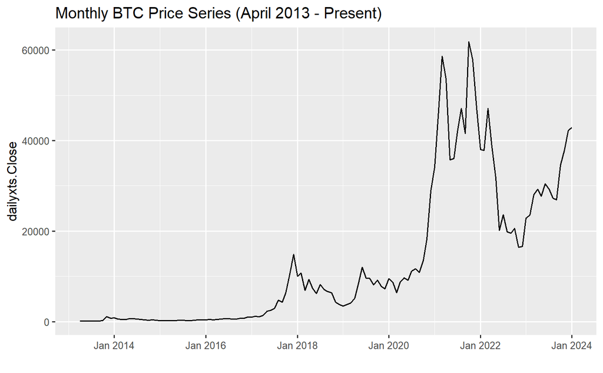

```r
ggplot(dfs_month$bitcoin,aes(x=Index, y=dailyxts.Close)) +
  geom_line() +
  xlab("") +
  ggtitle("Monthly BTC Price Series (April 2013 - Present)")
```

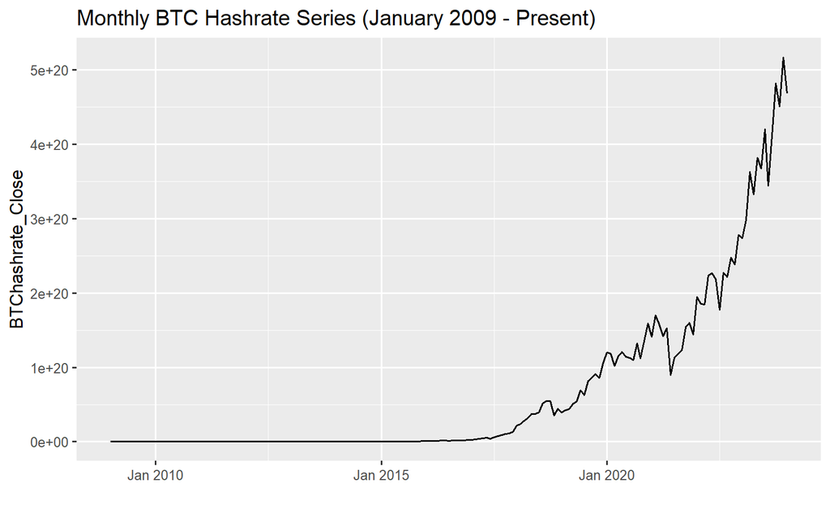

```r
ggplot(hashratexts,aes(x=Index, y=BTChashrate_Close)) +
  geom_line() +
  xlab("") +
  ggtitle("Monthly BTC Hashrate Series (January 2009 - Present)")
```

```r
# Calculate annualized growth rate of each hashrate measurement
hashratexts$loghash_High = log(hashratexts$BTChashrate_High)
hashratexts$BTChashgrowth_High = (hashratexts$loghash_High - lag(hashratexts$loghash_High))*12*100
hashratexts$loghash_Low = log(hashratexts$BTChashrate_Low)
hashratexts$BTChashgrowth_Low = (hashratexts$loghash_Low - lag(hashratexts$loghash_Low))*12*100
hashratexts$loghash_Close = log(hashratexts$BTChashrate_Close)
hashratexts$BTChashgrowth_Close = (hashratexts$loghash_Close - lag(hashratexts$loghash_Close))*12*100
hashratexts$loghash_Mid = log(hashratexts$BTChashrate_Mid)
hashratexts$BTChashgrowth_Mid = (hashratexts$loghash_Mid - lag(hashratexts$loghash_Mid))*12*100
```

```r
# Compile data frame of annualized crypto returns
assets_hash = merge(dfs_month$bitcoin$annret,
                   dfs_month$ethereum$annret,
                   dfs_month$`wrapped-bitcoin`$annret,
                   dfs_month$bitcoin$volgrowth,
                   dfs_month$ethereum$volgrowth,
                   dfs_month$`wrapped-bitcoin`$volgrowth)
# Correct variable names
colnames(assets_hash) = c("BTC", "ETH", "WBTC", "BTCvolgrowth", "ETHvolgrowth", "WBTCvolgrowth")
# Merge to hashrate data
assets_hash = merge(assets_hash[-1,], hashratexts)
# Bitcoin hashrate regressions (High, no lag)
hashreg_BTC_High_ALL = lm(BTC~BTChashgrowth_High, data=assets_hash)
summary(hashreg_BTC_High_ALL)
```

```
Call:
lm(formula = BTC ~ BTChashgrowth_High, data = assets_hash)

Residuals:
    Min      1Q  Median      3Q     Max
-601.62 -166.63  -20.34  164.21 1967.48

Coefficients:
                   Estimate Std. Error t value Pr(>|t|)
(Intercept)         38.7582    33.3609   1.162    0.248
BTChashgrowth_High   0.1001     0.1245   0.804    0.423

Residual standard error: 316 on 127 degrees of freedom
  (52 observations deleted due to missingness)
Multiple R-squared:  0.005066,  Adjusted R-squared:  -0.002768
F-statistic: 0.6467 on 1 and 127 DF,  p-value: 0.4228
```

```r
hashreg_BTC_High_5yr = lm(BTC~BTChashgrowth_High, data=tail(assets_hash,60))
summary(hashreg_BTC_High_5yr)
```

```
Call:
lm(formula = BTC ~ BTChashgrowth_High, data = tail(assets_hash,
    60))

Residuals:
    Min      1Q  Median      3Q     Max
-597.82 -152.53   -7.57  173.69  531.45

Coefficients:
                   Estimate Std. Error t value Pr(>|t|)
(Intercept)         62.6345    35.1995   1.779   0.0804 .
BTChashgrowth_High  -0.2375     0.2928  -0.811   0.4206
---
Signif. codes:  0 ‘***’ 0.001 ‘**’ 0.01 ‘*’ 0.05 ‘.’ 0.1 ‘ ’ 1

Residual standard error: 246.1 on 58 degrees of freedom
Multiple R-squared:  0.01122,   Adjusted R-squared:  -0.005832
F-statistic: 0.6579 on 1 and 58 DF,  p-value: 0.4206
```

```r
# Bitcoin hashrate regressions (High, 1mo lag)
hashreg_BTC_High_ALL_lag = lm(BTC~lag(BTChashgrowth_High), data=assets_hash)
summary(hashreg_BTC_High_ALL_lag)
```

```
Call:
lm(formula = BTC ~ lag(BTChashgrowth_High), data = assets_hash)

Residuals:
    Min      1Q  Median      3Q     Max
-648.82 -184.57  -20.49  180.14 1679.30

Coefficients:
                        Estimate Std. Error t value Pr(>|t|)
(Intercept)              10.2491    32.8611   0.312   0.7556
lag(BTChashgrowth_High)   0.2889     0.1220   2.367   0.0194 *
---
Signif. codes:  0 ‘***’ 0.001 ‘**’ 0.01 ‘*’ 0.05 ‘.’ 0.1 ‘ ’ 1

Residual standard error: 310 on 127 degrees of freedom
  (52 observations deleted due to missingness)
Multiple R-squared:  0.04227,   Adjusted R-squared:  0.03472
F-statistic: 5.605 on 1 and 127 DF,  p-value: 0.01942
```

```r
hashreg_BTC_High_5yr_lag = lm(BTC~lag(BTChashgrowth_High), data=tail(assets_hash,60))
summary(hashreg_BTC_High_5yr_lag)
```

```
Call:
lm(formula = BTC ~ lag(BTChashgrowth_High), data = tail(assets_hash,
    60))

Residuals:
    Min      1Q  Median      3Q     Max
-594.73 -144.66   -6.66  170.74  504.17

Coefficients:
                        Estimate Std. Error t value Pr(>|t|)
(Intercept)              57.6149    35.8533   1.607    0.114
lag(BTChashgrowth_High)  -0.1621     0.2961  -0.547    0.586

Residual standard error: 248.8 on 57 degrees of freedom
  (1 observation deleted due to missingness)
Multiple R-squared:  0.00523,   Adjusted R-squared:  -0.01222
F-statistic: 0.2997 on 1 and 57 DF,  p-value: 0.5862
```

```r
# Bitcoin hashrate regressions (Close, no lag)
hashreg_BTC_Close_ALL = lm(BTC~BTChashgrowth_Close, data=assets_hash)
summary(hashreg_BTC_Close_ALL)
```

```
Call:
lm(formula = BTC ~ BTChashgrowth_Close, data = assets_hash)

Residuals:
   Min     1Q Median     3Q    Max
-625.1 -196.5  -12.4  192.3 1953.1

Coefficients:
                    Estimate Std. Error t value Pr(>|t|)
(Intercept)          31.7326    31.6668   1.002    0.318
BTChashgrowth_Close   0.1504     0.1060   1.418    0.159

Residual standard error: 314.3 on 127 degrees of freedom
  (52 observations deleted due to missingness)
Multiple R-squared:  0.01559,   Adjusted R-squared:  0.00784
F-statistic: 2.011 on 1 and 127 DF,  p-value: 0.1586
```

```r
hashreg_BTC_Close_5yr = lm(BTC~BTChashgrowth_Close, data=tail(assets_hash,60))
summary(hashreg_BTC_Close_5yr)
```

```
Call:
lm(formula = BTC ~ BTChashgrowth_Close, data = tail(assets_hash,
    60))

Residuals:
    Min      1Q  Median      3Q     Max
-574.08 -152.25   21.61  199.33  511.48

Coefficients:
                    Estimate Std. Error t value Pr(>|t|)
(Intercept)          37.5584    32.6230   1.151    0.254
BTChashgrowth_Close   0.2576     0.1789   1.440    0.155

Residual standard error: 243.2 on 58 degrees of freedom
Multiple R-squared:  0.03452,   Adjusted R-squared:  0.01787
F-statistic: 2.074 on 1 and 58 DF,  p-value: 0.1552
```

```r
# Bitcoin hashrate regressions (Close, 1mo lag)
hashreg_BTC_Close_ALL_lag = lm(BTC~lag(BTChashgrowth_Close), data=assets_hash)
summary(hashreg_BTC_Close_ALL_lag)
```

```
Call:
lm(formula = BTC ~ lag(BTChashgrowth_Close), data = assets_hash)

Residuals:
    Min      1Q  Median      3Q     Max
-683.35 -180.37  -11.62  190.53 1640.96

Coefficients:
                         Estimate Std. Error t value Pr(>|t|)
(Intercept)                8.0091    31.0707   0.258  0.79700
lag(BTChashgrowth_Close)   0.3060     0.1035   2.956  0.00372 **
---
Signif. codes:  0 ‘***’ 0.001 ‘**’ 0.01 ‘*’ 0.05 ‘.’ 0.1 ‘ ’ 1

Residual standard error: 306.4 on 127 degrees of freedom
  (52 observations deleted due to missingness)
Multiple R-squared:  0.06438,   Adjusted R-squared:  0.05701
F-statistic: 8.738 on 1 and 127 DF,  p-value: 0.003715
```

```r
hashreg_BTC_Close_5yr_lag = lm(BTC~lag(BTChashgrowth_Close), data=tail(assets_hash,60))
summary(hashreg_BTC_Close_5yr_lag)
```

```
Call:
lm(formula = BTC ~ lag(BTChashgrowth_Close), data = tail(assets_hash,
    60))

Residuals:
    Min      1Q  Median      3Q     Max
-593.75 -146.60  -15.02  191.27  502.16

Coefficients:
                         Estimate Std. Error t value Pr(>|t|)
(Intercept)              44.84563   33.83675   1.325    0.190
lag(BTChashgrowth_Close)  0.08308    0.18466   0.450    0.654

Residual standard error: 249 on 57 degrees of freedom
  (1 observation deleted due to missingness)
Multiple R-squared:  0.003539,  Adjusted R-squared:  -0.01394
F-statistic: 0.2024 on 1 and 57 DF,  p-value: 0.6545
```

```r
# Combine best hashrate measure with volume growth for two-factor model
hashreg_BTC_opt = lm(BTC~BTCvolgrowth+lag(BTChashgrowth_Close), data=assets_hash[is.finite(assets_hash$BTCvolgrowth)])
summary(hashreg_BTC_opt)
```

```
Call:
lm(formula = BTC ~ BTCvolgrowth + lag(BTChashgrowth_Close), data = assets_hash[is.finite(assets_hash$BTCvolgrowth)])

Residuals:
    Min      1Q  Median      3Q     Max
-564.80 -169.49    2.14  187.46  511.80

Coefficients:
                         Estimate Std. Error t value Pr(>|t|)
(Intercept)              31.93222   26.40768   1.209   0.2290
BTCvolgrowth              0.07552    0.03551   2.127   0.0356 *
lag(BTChashgrowth_Close)  0.02910    0.11221   0.259   0.7958
---
Signif. codes:  0 ‘***’ 0.001 ‘**’ 0.01 ‘*’ 0.05 ‘.’ 0.1 ‘ ’ 1

Residual standard error: 256 on 117 degrees of freedom
  (1 observation deleted due to missingness)
Multiple R-squared:  0.03793,   Adjusted R-squared:  0.02148
F-statistic: 2.306 on 2 and 117 DF,  p-value: 0.1042
```

```r
cor(assets_hash[is.finite(assets_hash$BTCvolgrowth)], use="pairwise.complete.obs") |> round(2)
```

```
                      BTC   ETH  WBTC BTCvolgrowth ETHvolgrowth WBTCvolgrowth
BTC                  1.00  0.58  1.00         0.19         0.11          0.12
ETH                  0.58  1.00  0.80         0.15         0.62          0.09
WBTC                 1.00  0.80  1.00         0.29         0.13          0.12
BTCvolgrowth         0.19  0.15  0.29         1.00         0.41          0.46
ETHvolgrowth         0.11  0.62  0.13         0.41         1.00          0.51
WBTCvolgrowth        0.12  0.09  0.12         0.46         0.51          1.00
BTChashrate_Open    -0.03 -0.11 -0.10        -0.11        -0.15         -0.25
BTChashrate_High    -0.02 -0.12 -0.08        -0.10        -0.15         -0.24
BTChashrate_Low     -0.01 -0.11 -0.05        -0.09        -0.12         -0.20
BTChashrate_Close    0.00 -0.11 -0.04        -0.10        -0.13         -0.21
BTChashrate_Mid     -0.02 -0.11 -0.07        -0.10        -0.14         -0.23
loghash_High         0.04 -0.19 -0.16        -0.13        -0.17         -0.30
BTChashgrowth_High  -0.04  0.07 -0.11         0.11         0.13          0.10
loghash_Low          0.04 -0.19 -0.13        -0.13        -0.16         -0.24
BTChashgrowth_Low   -0.05  0.13  0.20         0.15         0.28          0.25
loghash_Close        0.05 -0.18 -0.10        -0.12        -0.16         -0.27
BTChashgrowth_Close  0.07  0.12  0.18         0.11         0.11          0.06
loghash_Mid          0.04 -0.19 -0.14        -0.13        -0.17         -0.29
BTChashgrowth_Mid   -0.03  0.14  0.11         0.15         0.28          0.16
                    BTChashrate_Open BTChashrate_High BTChashrate_Low
BTC                            -0.03            -0.02           -0.01
ETH                            -0.11            -0.12           -0.11
WBTC                           -0.10            -0.08           -0.05
BTCvolgrowth                   -0.11            -0.10           -0.09
ETHvolgrowth                   -0.15            -0.15           -0.12
WBTCvolgrowth                  -0.25            -0.24           -0.20
BTChashrate_Open                1.00             0.99            0.99
BTChashrate_High                0.99             1.00            0.99
BTChashrate_Low                 0.99             0.99            1.00
BTChashrate_Close               0.98             0.99            0.99
BTChashrate_Mid                 1.00             1.00            0.99
loghash_High                    0.74             0.74            0.74
BTChashgrowth_High             -0.28            -0.27           -0.27
loghash_Low                     0.74             0.74            0.74
BTChashgrowth_Low              -0.23            -0.23           -0.17
loghash_Close                   0.74             0.74            0.74
BTChashgrowth_Close            -0.26            -0.24           -0.22
loghash_Mid                     0.74             0.74            0.74
BTChashgrowth_Mid              -0.27            -0.27           -0.25
```

[output cut: 65 more lines]

```
ETHvolgrowth                     0.28
WBTCvolgrowth                    0.16
BTChashrate_Open                -0.27
BTChashrate_High                -0.27
BTChashrate_Low                 -0.25
BTChashrate_Close               -0.25
BTChashrate_Mid                 -0.26
loghash_High                    -0.47
BTChashgrowth_High               0.74
loghash_Low                     -0.47
BTChashgrowth_Low                0.63
loghash_Close                   -0.46
BTChashgrowth_Close              0.79
loghash_Mid                     -0.47
BTChashgrowth_Mid                1.00
```

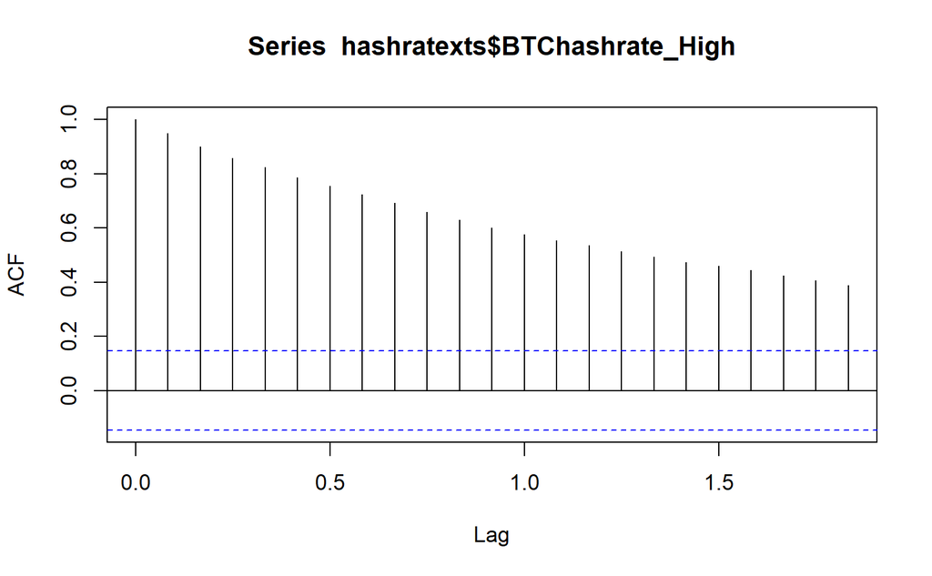

```r
acf(hashratexts$BTChashrate_High)
```

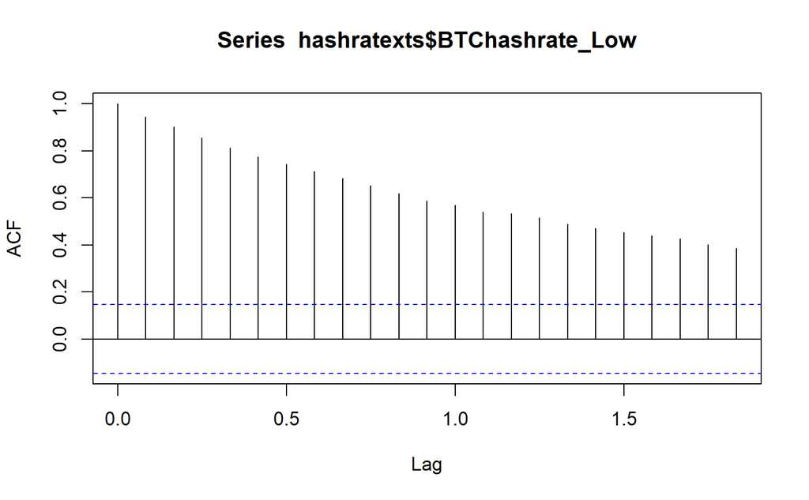

```r
acf(hashratexts$BTChashrate_Low)
```

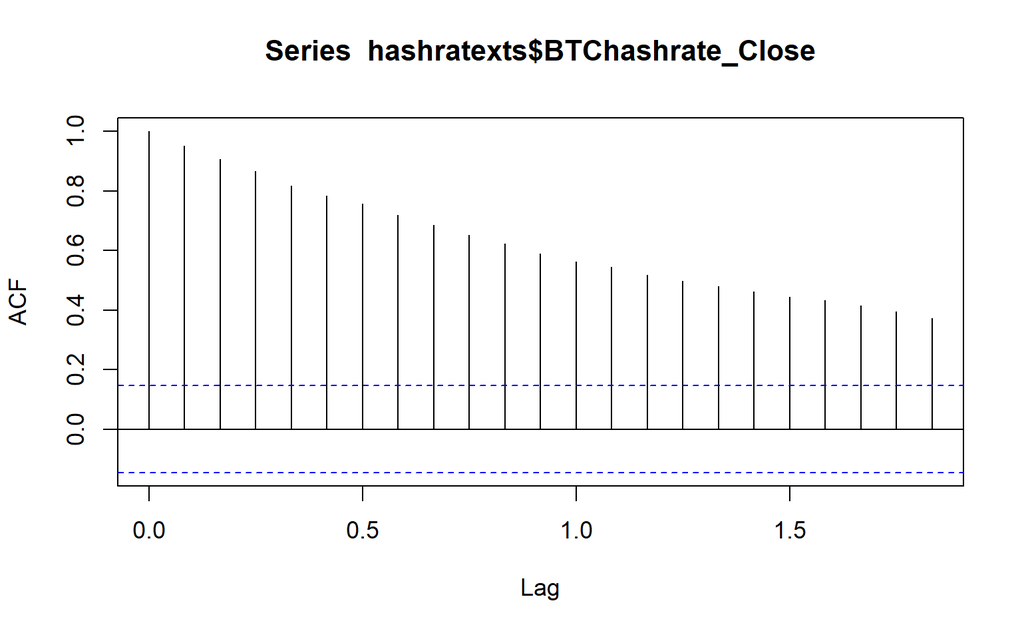

```r
acf(hashratexts$BTChashrate_Close)
```

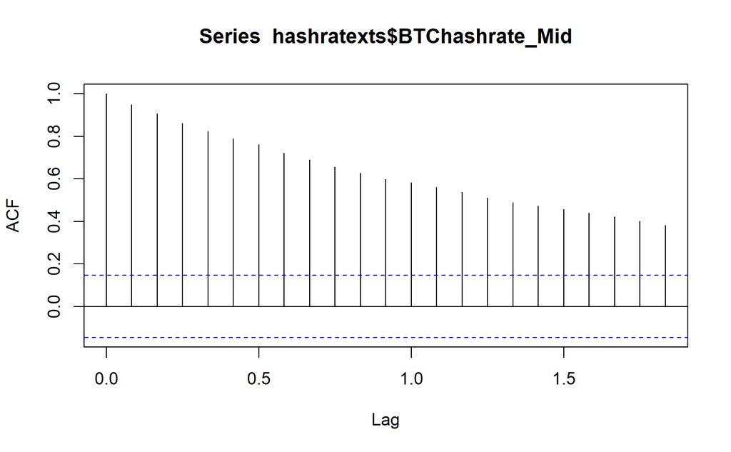

```r
acf(hashratexts$BTChashrate_Mid)
```

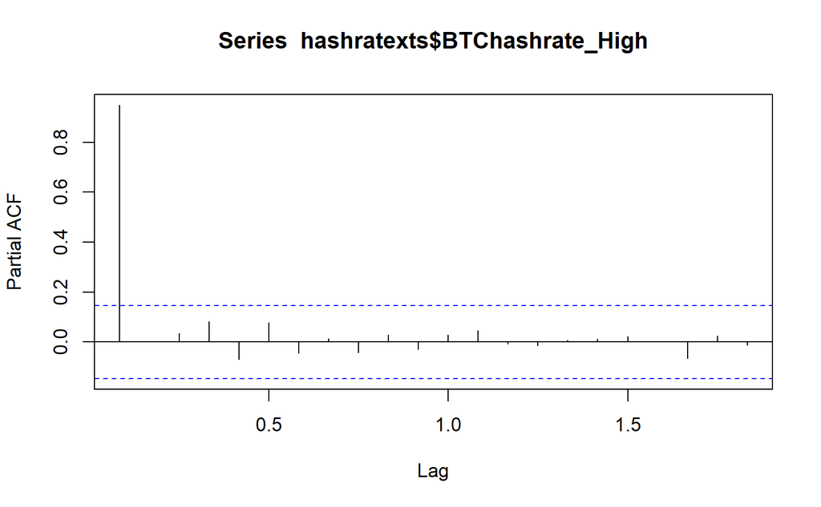

```r
pacf(hashratexts$BTChashrate_High)
```

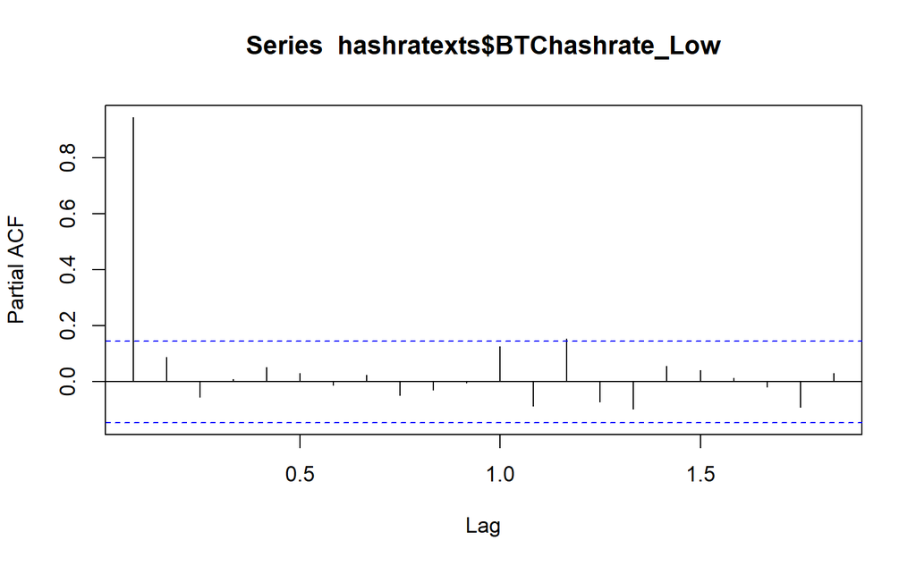

```r
pacf(hashratexts$BTChashrate_Low)
```

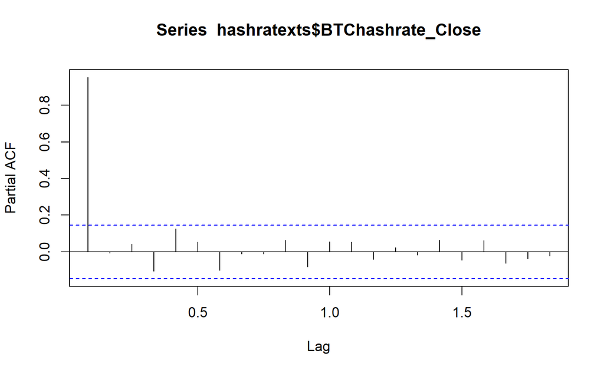

```r
pacf(hashratexts$BTChashrate_Close)
```

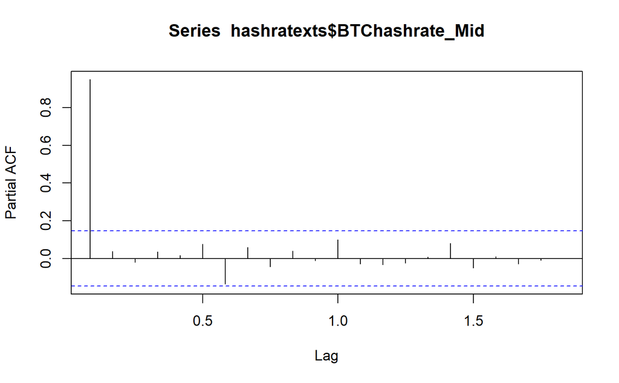

```r
pacf(hashratexts$BTChashrate_Mid)
```

```r
#
adf.test(hashratexts$BTChashrate_High)
```

```
    Augmented Dickey-Fuller Test

data:  hashratexts$BTChashrate_High
Dickey-Fuller = 4.6141, Lag order = 5, p-value = 0.99
alternative hypothesis: stationary
```

```r
adf.test(hashratexts$BTChashrate_Low)
```

```
    Augmented Dickey-Fuller Test

data:  hashratexts$BTChashrate_Low
Dickey-Fuller = 5.0832, Lag order = 5, p-value = 0.99
alternative hypothesis: stationary
```

```r
adf.test(hashratexts$BTChashrate_Close)
```

```
    Augmented Dickey-Fuller Test

data:  hashratexts$BTChashrate_Close
Dickey-Fuller = 2.9097, Lag order = 5, p-value = 0.99
alternative hypothesis: stationary
```

```r
adf.test(hashratexts$BTChashrate_Mid)
```

```
    Augmented Dickey-Fuller Test

data:  hashratexts$BTChashrate_Mid
Dickey-Fuller = 4.9081, Lag order = 5, p-value = 0.99
alternative hypothesis: stationary
```

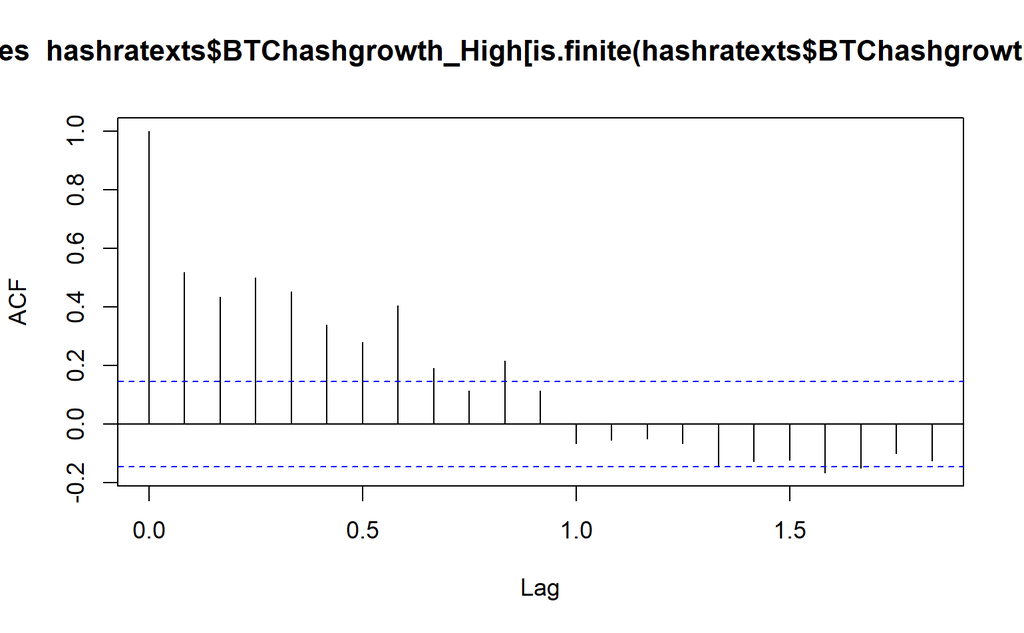

```r
acf(hashratexts$BTChashgrowth_High[is.finite(hashratexts$BTChashgrowth_High)])
```

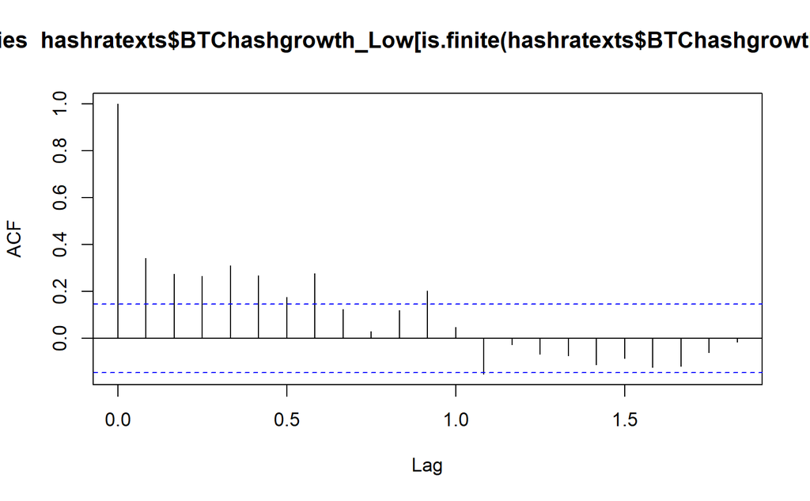

```r
acf(hashratexts$BTChashgrowth_Low[is.finite(hashratexts$BTChashgrowth_Low)])
```

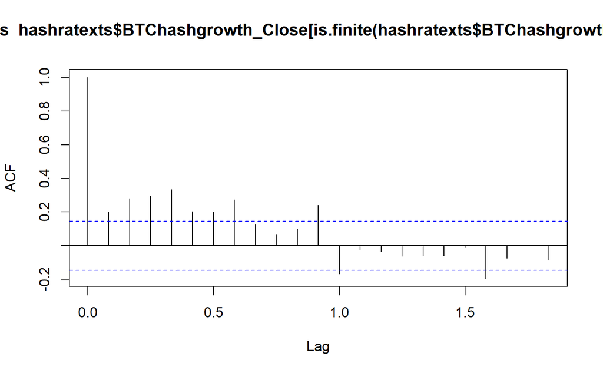

```r
acf(hashratexts$BTChashgrowth_Close[is.finite(hashratexts$BTChashgrowth_Close)])
```

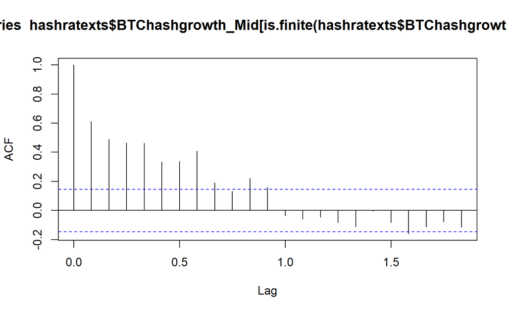

```r
acf(hashratexts$BTChashgrowth_Mid[is.finite(hashratexts$BTChashgrowth_Mid)])
```

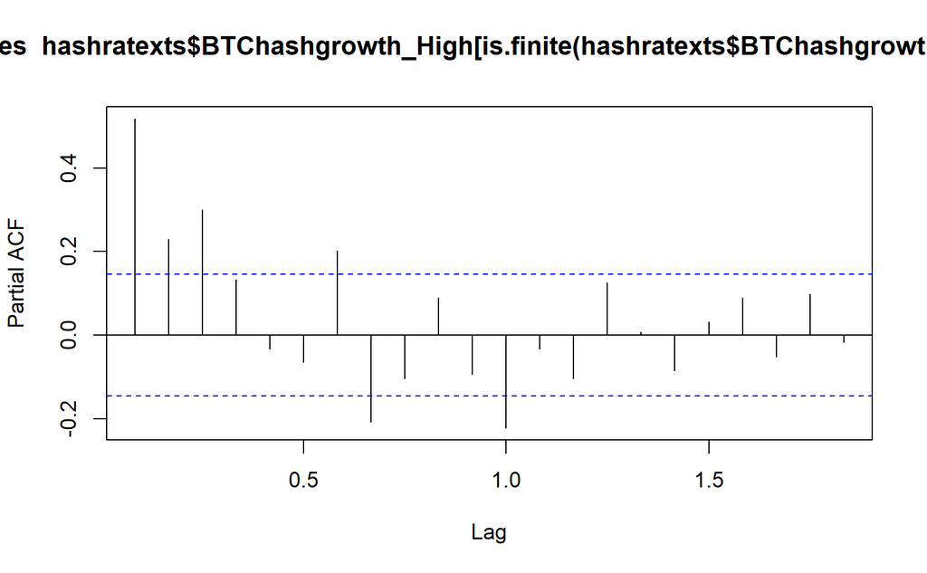

```r
pacf(hashratexts$BTChashgrowth_High[is.finite(hashratexts$BTChashgrowth_High)])
```

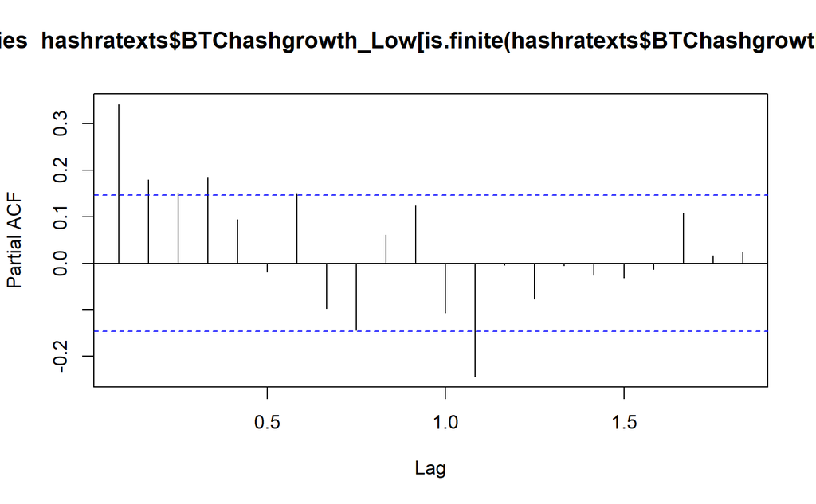

```r
pacf(hashratexts$BTChashgrowth_Low[is.finite(hashratexts$BTChashgrowth_Low)])
```

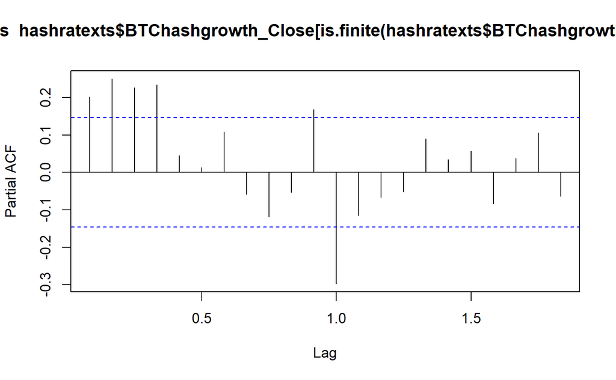

```r
pacf(hashratexts$BTChashgrowth_Close[is.finite(hashratexts$BTChashgrowth_Close)])
```

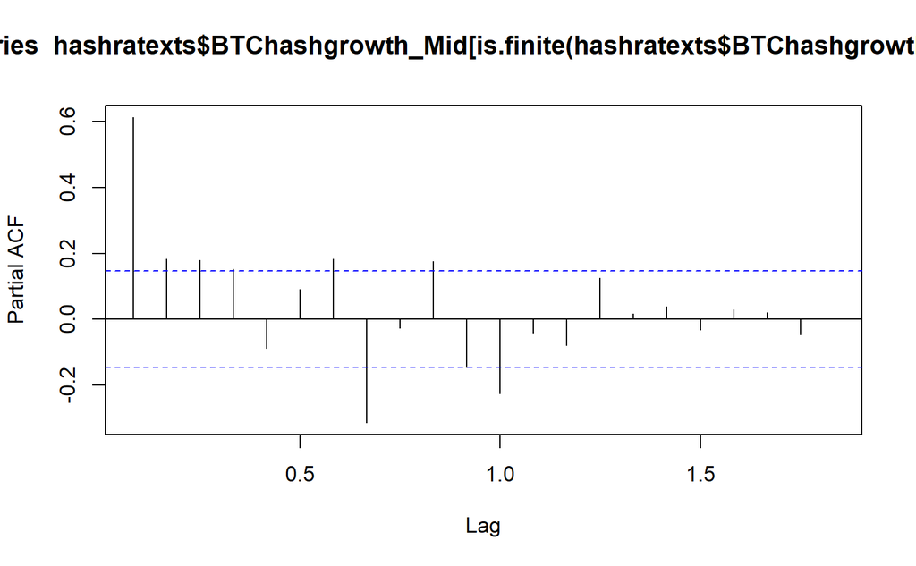

```r
pacf(hashratexts$BTChashgrowth_Mid[is.finite(hashratexts$BTChashgrowth_Mid)])
```

```r
#
adf.test(hashratexts$BTChashgrowth_High[is.finite(hashratexts$BTChashgrowth_High)])
```

```
    Augmented Dickey-Fuller Test

data:  hashratexts$BTChashgrowth_High[is.finite(hashratexts$BTChashgrowth_High)]
Dickey-Fuller = -4.2419, Lag order = 5, p-value = 0.01
alternative hypothesis: stationary
```

```r
adf.test(hashratexts$BTChashgrowth_Low[is.finite(hashratexts$BTChashgrowth_Low)])
```

```
    Augmented Dickey-Fuller Test

data:  hashratexts$BTChashgrowth_Low[is.finite(hashratexts$BTChashgrowth_Low)]
Dickey-Fuller = -4.8257, Lag order = 5, p-value = 0.01
alternative hypothesis: stationary
```

```r
adf.test(hashratexts$BTChashgrowth_Close[is.finite(hashratexts$BTChashgrowth_Close)])
```

```
    Augmented Dickey-Fuller Test

data:  hashratexts$BTChashgrowth_Close[is.finite(hashratexts$BTChashgrowth_Close)]
Dickey-Fuller = -5.4013, Lag order = 5, p-value = 0.01
alternative hypothesis: stationary
```

```r
adf.test(hashratexts$BTChashgrowth_Mid[is.finite(hashratexts$BTChashgrowth_Mid)])
```

```
    Augmented Dickey-Fuller Test

data:  hashratexts$BTChashgrowth_Mid[is.finite(hashratexts$BTChashgrowth_Mid)]
Dickey-Fuller = -4.2474, Lag order = 5, p-value = 0.01
alternative hypothesis: stationary
```